# Analysis of lifts

Author

Stan Brouwer

This is the code used to analyse the biomechanical characteristics of each lift.

Lets load all lift data and calculate peak and average linear and angular accelerations

```r
loadLift <- function(dir) {
  files <- list.files(path = dir, full.names = TRUE)
  data <- list()

  for (i in seq_along(files)) {
    data[[i]] <- read.csv(files[i])
  }
  return(data)
}

# Load the data
data_male <- loadLift("../../lifts/male")
data_female <- loadLift("../../lifts/female")

# Function to find the maximum value for each attribute for the lift
find_col_max <- function(df_list, colname) {
  # Initialize a matrix to store the maximum values
  col_max <- matrix(NA, nrow = length(df_list), ncol = 5)
  colnames(col_max) <- c(paste0(colname, "1"), paste0(colname, "2"), paste0(colname, "3"), paste0(colname, "4"), paste0(colname, "5"))

  for (i in seq_along(df_list)) {
    df <- df_list[[i]]
    for (j in 1:5) {
      col_max[i, j] <- max(df[[paste0(colname, j)]], na.rm = TRUE)
    }
  }
  # Convert the matrix to a dataframe
  col_max_df <- as.data.frame(col_max)

  return(col_max_df)
}

# Function to find the average value for each attribute for the lift
find_col_mean <- function(df_list, colname) {
  # Initialize a matrix to store the mean values
  col_mean <- matrix(NA, nrow = length(df_list), ncol = 5)
  colnames(col_mean) <- c(paste0(colname, "1"), paste0(colname, "2"), paste0(colname, "3"), paste0(colname, "4"), paste0(colname, "5"))

  for (i in seq_along(df_list)) {
    df <- df_list[[i]]
    for (j in 1:5) {
      col_mean[i, j] <- mean(df[[paste0(colname, j)]], na.rm = TRUE)
    }
  }
  # Convert the matrix to a dataframe
  col_mean_df <- as.data.frame(col_mean)

  return(col_mean_df)
}

# calculate peak accelerations
male_PLA <- find_col_max(data_male, "A_abs")
male_PAA <- find_col_max(data_male, "Gyr_abs")
female_PLA <- find_col_max(data_female, "A_abs")
female_PAA <- find_col_max(data_female, "Gyr_abs")

# calculate average accelerations
male_ALA <- find_col_mean(data_male, "A_abs")
male_AAA <- find_col_mean(data_male, "Gyr_abs")
female_ALA <- find_col_mean(data_female, "A_abs")
female_AAA <- find_col_mean(data_female, "Gyr_abs")

names(male_PLA) <- paste0(names(male_PLA), "_PLA")
names(male_PAA) <- paste0(names(male_PAA), "_PAA")
names(male_ALA) <- paste0(names(male_ALA), "_ALA")
names(male_AAA) <- paste0(names(male_AAA), "_AAA")
names(female_PLA) <- paste0(names(female_PLA), "_PLA")
names(female_PAA) <- paste0(names(female_PAA), "_PAA")
names(female_ALA) <- paste0(names(female_ALA), "_ALA")
names(female_AAA) <- paste0(names(female_AAA), "_AAA")

# Combine the data into dataframes
d_male <- cbind(male_PLA, male_PAA, male_ALA, male_AAA)
d_female <- cbind(female_PLA, female_PAA, female_ALA, female_AAA)

# Add a group column to each dataframe
d_male <- d_male %>% mutate(group = "male")
d_female <- d_female %>% mutate(group = "female")

# Combine the dataframes
data <- bind_rows(d_male, d_female)

# Rename data headers
data <- data %>%
  rename(PLA1 = A_abs1_PLA) %>%
  rename(PLA2 = A_abs2_PLA) %>%
  rename(PLA3 = A_abs3_PLA) %>%
  rename(PLA4 = A_abs4_PLA) %>%
  rename(PLA5 = A_abs5_PLA) %>%
  rename(ALA1 = A_abs1_ALA) %>%
  rename(ALA2 = A_abs2_ALA) %>%
  rename(ALA3 = A_abs3_ALA) %>%
  rename(ALA4 = A_abs4_ALA) %>%
  rename(ALA5 = A_abs5_ALA) %>%
  rename(PAA1 = Gyr_abs1_PAA) %>%
  rename(PAA2 = Gyr_abs2_PAA) %>%
  rename(PAA3 = Gyr_abs3_PAA) %>%
  rename(PAA4 = Gyr_abs4_PAA) %>%
  rename(PAA5 = Gyr_abs5_PAA) %>%
  rename(AAA1 = Gyr_abs1_AAA) %>%
  rename(AAA2 = Gyr_abs2_AAA) %>%
  rename(AAA3 = Gyr_abs3_AAA) %>%
  rename(AAA4 = Gyr_abs4_AAA) %>%
  rename(AAA5 = Gyr_abs5_AAA)

# Round all numerical data in the dataframe
datarounded <- data %>%
  mutate(across(where(is.numeric), ~ round(., 2)))
# Showing only first 10 rows
knitr::kable(datarounded, caption = "Table X: PLA, ALA, PAA and AAA for each marker per participant") %>%
  kableExtra::kable_styling(bootstrap_options = "striped")
```

Table X: PLA, ALA, PAA and AAA for each marker per participant

| PLA1 | PLA2 | PLA3 | PLA4 | PLA5 | PAA1 | PAA2 | PAA3 | PAA4 | PAA5 | ALA1 | ALA2 | ALA3 | ALA4 | ALA5 | AAA1 | AAA2 | AAA3 | AAA4 | AAA5 | group |
| --- | --- | --- | --- | --- | --- | --- | --- | --- | --- | --- | --- | --- | --- | --- | --- | --- | --- | --- | --- | --- |
| 18.28 | 36.83 | 23.90 | 18.62 | 21.61 | 469.85 | 400.38 | 545.16 | 105.14 | 362.98 | 10.01 | 12.60 | 11.86 | 10.88 | 11.16 | 59.48 | 90.97 | 110.86 | 30.80 | 74.80 | male |
| 21.33 | 26.26 | 21.11 | 20.36 | 21.43 | 162.24 | 295.52 | 212.82 | 158.95 | 412.07 | 9.74 | 11.49 | 11.04 | 10.47 | 10.69 | 44.26 | 59.99 | 48.27 | 32.03 | 103.02 | male |
| 15.99 | 145.17 | 59.99 | 37.66 | 19.23 | 16.91 | 472.49 | 408.23 | 189.71 | 408.49 | 9.85 | 14.35 | 13.72 | 11.27 | 10.88 | 4.32 | 93.07 | 89.53 | 42.62 | 81.23 | male |
| 16.23 | 79.55 | 62.69 | 33.00 | 25.64 | 14.98 | 574.64 | 391.29 | 176.59 | 402.92 | 9.77 | 14.60 | 13.99 | 11.57 | 10.96 | 5.39 | 92.47 | 94.97 | 41.25 | 74.70 | male |
| 20.69 | 33.19 | 19.86 | 20.08 | 21.77 | 172.68 | 297.68 | 229.01 | 167.39 | 463.36 | 9.91 | 12.71 | 11.37 | 10.68 | 11.33 | 42.52 | 93.40 | 61.01 | 38.01 | 106.18 | male |
| 20.18 | 65.96 | 31.89 | 29.47 | 29.89 | 218.32 | 306.38 | 232.02 | 156.21 | 519.07 | 9.78 | 12.28 | 11.07 | 10.41 | 11.13 | 42.60 | 74.73 | 68.44 | 33.57 | 102.15 | male |
| 19.42 | 40.37 | 23.66 | 21.93 | 19.92 | 278.87 | 383.21 | 222.32 | 142.26 | 438.72 | 9.93 | 12.82 | 11.51 | 10.79 | 11.05 | 39.51 | 83.27 | 69.93 | 37.41 | 97.44 | male |
| 20.49 | 47.57 | 21.16 | 25.57 | 22.10 | 317.98 | 293.72 | 225.04 | 147.64 | 429.42 | 9.85 | 12.45 | 11.47 | 10.80 | 11.27 | 48.64 | 89.81 | 69.34 | 41.25 | 105.83 | male |
| 19.46 | 123.71 | 68.15 | 37.95 | 31.24 | 30.71 | 447.37 | 378.95 | 152.08 | 405.70 | 10.27 | 14.05 | 13.89 | 11.56 | 12.11 | 7.22 | 99.12 | 117.03 | 46.64 | 93.47 | male |
| 17.94 | 134.63 | 87.32 | 55.14 | 31.52 | 12.96 | 510.08 | 415.35 | 167.52 | 439.30 | 10.25 | 15.06 | 13.95 | 11.55 | 11.45 | 8.55 | 109.13 | 111.26 | 47.88 | 91.46 | male |
| 16.34 | 119.94 | 79.21 | 42.86 | 27.21 | 20.19 | 571.61 | 416.39 | 151.02 | 416.25 | 10.06 | 14.57 | 13.99 | 11.58 | 11.43 | 6.75 | 97.73 | 101.05 | 43.21 | 83.37 | male |
| 21.33 | 26.26 | 21.11 | 20.36 | 21.43 | 162.24 | 295.52 | 212.82 | 158.95 | 412.07 | 9.72 | 11.55 | 11.07 | 10.49 | 10.74 | 41.04 | 64.03 | 52.01 | 32.96 | 99.08 | female |
| 20.69 | 33.19 | 19.86 | 20.08 | 21.77 | 266.94 | 297.68 | 229.01 | 167.39 | 463.36 | 9.62 | 12.06 | 11.03 | 10.54 | 11.01 | 56.40 | 76.03 | 49.91 | 33.35 | 109.73 | female |
| 20.18 | 65.96 | 31.89 | 29.47 | 29.89 | 218.32 | 306.38 | 232.02 | 156.21 | 519.07 | 9.78 | 12.28 | 11.07 | 10.41 | 11.13 | 42.60 | 74.73 | 68.44 | 33.57 | 102.15 | female |
| 19.42 | 40.37 | 23.66 | 21.93 | 19.92 | 278.87 | 383.21 | 222.32 | 142.26 | 438.72 | 9.80 | 12.16 | 11.18 | 10.64 | 10.78 | 37.80 | 69.06 | 58.55 | 33.13 | 90.75 | female |
| 20.49 | 47.57 | 23.36 | 25.57 | 22.10 | 317.98 | 314.07 | 294.65 | 147.64 | 429.42 | 9.78 | 13.30 | 11.56 | 10.79 | 11.25 | 47.27 | 104.11 | 79.75 | 41.43 | 103.95 | female |
| 19.20 | 36.75 | 22.33 | 18.90 | 19.85 | 234.42 | 287.75 | 214.17 | 136.34 | 396.77 | 9.82 | 11.81 | 10.86 | 10.40 | 10.69 | 34.74 | 66.14 | 56.64 | 30.77 | 86.53 | female |
| 18.54 | 34.81 | 26.56 | 21.42 | 25.55 | 613.66 | 216.34 | 320.64 | 100.38 | 422.10 | 10.18 | 11.79 | 11.20 | 11.27 | 11.50 | 75.62 | 55.57 | 89.97 | 30.69 | 77.40 | female |
| 19.73 | 32.00 | 20.69 | 19.55 | 19.95 | 620.34 | 778.19 | 449.50 | 123.27 | 424.41 | 10.08 | 11.10 | 10.97 | 10.83 | 10.92 | 62.24 | 68.55 | 87.43 | 24.34 | 68.81 | female |
| 21.33 | 26.26 | 21.11 | 20.36 | 21.43 | 162.24 | 295.52 | 212.82 | 158.95 | 412.07 | 9.79 | 11.75 | 11.20 | 10.55 | 10.77 | 35.37 | 70.03 | 56.40 | 35.08 | 98.07 | female |
| 17.81 | 61.22 | 28.66 | 28.80 | 17.90 | 339.33 | 401.71 | 244.02 | 188.66 | 431.03 | 9.88 | 12.81 | 11.22 | 10.83 | 10.99 | 38.49 | 84.25 | 69.44 | 48.34 | 80.24 | female |
| 20.69 | 33.19 | 19.86 | 20.08 | 21.77 | 172.68 | 297.68 | 229.01 | 167.39 | 463.36 | 9.92 | 12.70 | 11.33 | 10.67 | 11.34 | 42.18 | 92.99 | 60.92 | 37.63 | 105.63 | female |

## Descriptive statistics

Lets check assumptions by - Reporting descriptives [mean ± std] - Levene’s test for equality of variances - Shapiro-Wilk’s test for normality - Z-value for skewness - Z-value for kurtosis - Histograms - Q-Q plots

### Some descriptives

Start by calculating means and std. I took some steps to format it to [mean ± std] format

```r
# Calculate the number of participants overall and by sex
count_summary <- data %>%
  group_by(group) %>%
  summarise(count = n()) %>%
  bind_rows(summarise(data, group = "Overall", count = n()))

# Calculate the summary statistics for all subjects
column_names <- setdiff(names(data), "group")
overall_summary <- data %>%
  summarise(across(column_names,
                   list(mean = ~ round(mean(.x, na.rm = TRUE), 2),
                        sd = ~ sprintf("%.2f", sd(.x, na.rm = TRUE)))), 2)

# Calculate the summary statistics by sex
sex_summary <- data %>%
  group_by(group) %>%
  summarise(across(column_names,
                   list(mean = ~ round(mean(.x, na.rm = TRUE), 2),
                        sd = ~ sprintf("%.2f", sd(.x, na.rm = TRUE)))), 2)

# Combine the summaries into a single table
summary_table <- bind_rows(
  overall_summary %>% mutate(group = "Overall"),
  sex_summary
)

# Reshape the table for better visualization
summary_table <- summary_table %>%
  pivot_longer(cols = -group,
               names_to = c("variable", ".value"),
               names_sep = "_") %>%
  pivot_wider(names_from = group, values_from = c(mean, sd))

# Combine mean and sd into a single column
summary_table <- summary_table %>%
  mutate(across(ends_with("_Overall"), ~ ifelse(is.na(.), "", as.character(.))),
         Overall = paste0(mean_Overall, " ± ", sd_Overall)) %>%
  mutate(across(ends_with("_male"), ~ ifelse(is.na(.), "", as.character(.))),
         male = paste0(mean_male, " ± ", sd_male)) %>%
  mutate(across(ends_with("_female"), ~ ifelse(is.na(.), "", as.character(.))),
         female = paste0(mean_female, " ± ", sd_female)) %>%
  select(variable, Overall, male, female)

# Prepare the participant counts in the correct format
participant_counts <- count_summary %>%
  pivot_wider(names_from = group, values_from = count) %>%
  mutate(variable = "count",
         Overall = as.character(Overall),
         male = as.character(male),
         female = as.character(female))

# Combine the participant counts with the summary statistics
final_summary_table <- bind_rows(participant_counts, summary_table)

# Correct the NA values for combined mean ± sd columns
final_summary_table <- final_summary_table %>%
  mutate(Overall = ifelse(is.na(Overall), "", Overall),
         male = ifelse(is.na(male), "", male),
         female = ifelse(is.na(female), "", female))

# Change the order of the columns, edit some names
final_summary_table <- final_summary_table %>%
  select(variable, Overall, male, female)

library(gtExtras)
# Print the table using knitr::kable
knitr::kable(final_summary_table[1:21,], caption = "Table X: summary of PLA PAA ALA and AAA") %>%
  kableExtra::kable_styling(bootstrap_options = "striped")
```

Table X: summary of PLA PAA ALA and AAA

| variable | Overall | male | female |
| --- | --- | --- | --- |
| count | 22 | 11 | 11 |
| PLA1 | 19.35 ± 1.66 | 18.76 ± 1.93 | 19.95 ± 1.13 |
| PLA2 | 58.67 ± 37.82 | 77.56 ± 45.20 | 39.78 ± 13.24 |
| PLA3 | 34.46 ± 21.43 | 45.36 ± 26.22 | 23.56 ± 3.92 |
| PLA4 | 26.78 ± 9.47 | 31.15 ± 11.49 | 22.41 ± 3.76 |
| PLA5 | 23.32 ± 4.13 | 24.69 ± 4.60 | 21.96 ± 3.25 |
| PAA1 | 231.94 ± 173.71 | 155.97 ± 154.23 | 307.91 ± 163.97 |
| PAA2 | 383.05 ± 131.57 | 413.92 ± 109.16 | 352.19 ± 149.47 |
| PAA3 | 297.16 ± 100.29 | 334.23 ± 113.69 | 260.09 ± 71.92 |
| PAA4 | 152.82 ± 22.52 | 155.86 ± 21.72 | 149.77 ± 23.93 |
| PAA5 | 432.3 ± 36.49 | 427.12 ± 39.88 | 437.49 ± 33.86 |
| ALA1 | 9.9 ± 0.17 | 9.95 ± 0.18 | 9.85 ± 0.16 |
| ALA2 | 12.74 ± 1.13 | 13.36 ± 1.19 | 12.12 ± 0.63 |
| ALA3 | 11.84 ± 1.17 | 12.53 ± 1.34 | 11.15 ± 0.19 |
| ALA4 | 10.86 ± 0.41 | 11.05 ± 0.46 | 10.67 ± 0.25 |
| ALA5 | 11.12 ± 0.34 | 11.22 ± 0.38 | 11.01 ± 0.27 |
| AAA1 | 37.41 ± 19.68 | 28.11 ± 21.38 | 46.7 ± 12.88 |
| AAA2 | 82.24 ± 15.10 | 89.43 ± 13.09 | 75.04 ± 13.91 |
| AAA3 | 75.96 ± 21.19 | 85.61 ± 23.30 | 66.31 ± 13.98 |
| AAA4 | 37.09 ± 6.33 | 39.51 ± 5.69 | 34.66 ± 6.23 |
| AAA5 | 92.55 ± 12.31 | 92.15 ± 11.98 | 92.94 ± 13.21 |

### Levene’s test

Lets run levene’s test to determine equality of variance

```r
library(car)

# Get the numerical columns from the dataframe
num_cols <- sapply(data, is.numeric)

# Exclude the column 'Sex' as it is categorical
num_cols <- num_cols & names(data) != "group"

# Initialize a list to store the test results
levene_results <- list()

# Perform Levene's test for each numerical column
for (col in names(data)[num_cols]) {
  test_result <- leveneTest(data[[col]] ~ data$group)
  levene_results[[col]] <- test_result
}

# Extract the necessary information from the test results
results_table <- data.frame(
  Variable = character(),
  F_Value = numeric(),
  Pr_Greater_F = numeric(),
  stringsAsFactors = FALSE
)

for (col in names(levene_results)) {
  test_result <- levene_results[[col]]
  results_table <- rbind(results_table, data.frame(
    Variable = col,
    F_Value = round(test_result$`F value`[1],2),
    Pr_Greater_F = round(test_result$`Pr(>F)`[1],2)
  ))
}

# Print the results in a nice table
knitr::kable(results_table, caption = "Table X: Levene's test results on participants' characteristics") %>%
  kableExtra::kable_styling(bootstrap_options = "striped")
```

Table X: Levene's test results on participants' characteristics

| Variable | F_Value | Pr_Greater_F |
| --- | --- | --- |
| PLA1 | 2.70 | 0.12 |
| PLA2 | 12.99 | 0.00 |
| PLA3 | 12.59 | 0.00 |
| PLA4 | 8.43 | 0.01 |
| PLA5 | 1.80 | 0.20 |
| PAA1 | 0.08 | 0.78 |
| PAA2 | 0.17 | 0.68 |
| PAA3 | 3.55 | 0.07 |
| PAA4 | 0.15 | 0.70 |
| PAA5 | 0.14 | 0.71 |
| ALA1 | 0.37 | 0.55 |
| ALA2 | 4.08 | 0.06 |
| ALA3 | 16.41 | 0.00 |
| ALA4 | 4.95 | 0.04 |
| ALA5 | 0.31 | 0.58 |
| AAA1 | 3.35 | 0.08 |
| AAA2 | 0.10 | 0.76 |
| AAA3 | 3.86 | 0.06 |
| AAA4 | 0.08 | 0.78 |
| AAA5 | 0.05 | 0.83 |

## Shapiro-Wilk test

Test the normality

```r
library(car)

# Filter the data by sex
data_male <- data %>% filter(group == "male")
data_female <- data %>% filter(group == "female")

# Initialize lists to store the test results
shapiro_test_male <- list()
shapiro_test_female <- list()

# Perform Shapiro-Wilk test for each specified column
for (i in colnames(data)[1:20]) { # Adjust the column indices based on actual data structure
  shapiro_test_male[[i]] <- shapiro.test(data_male[[i]])
  shapiro_test_female[[i]] <- shapiro.test(data_female[[i]])
}

# Extract the necessary information from the test results
results_male <- data.frame(
  Variable = character(),
  Statistic_Male = numeric(),
  P_Value_Male = numeric(),
  stringsAsFactors = FALSE
)

results_female <- data.frame(
  Variable = character(),
  Statistic_Female = numeric(),
  P_Value_Female = numeric(),
  stringsAsFactors = FALSE
)

for (col in names(shapiro_test_male)) {
  test_result_male <- shapiro_test_male[[col]]
  results_male <- rbind(results_male, data.frame(
    Variable = col,
    Statistic_Male = round(test_result_male$statistic,2),
    P_Value_Male = round(test_result_male$p.value,2)
  ))
}

for (col in names(shapiro_test_female)) {
  test_result_female <- shapiro_test_female[[col]]
  results_female <- rbind(results_female, data.frame(
    Variable = col,
    Statistic_Female = round(test_result_female$statistic,2),
    P_Value_Female = round(test_result_female$p.value,2)
  ))
}

# Combine the results into one table
results_table <- merge(results_male, results_female, by = "Variable")

# Print the results in a nice table
knitr::kable(results_table, caption = "Table X: Shapiro-Wilk's test results on participants' characteristics") %>%
  kableExtra::kable_styling(bootstrap_options = "striped")
```

Table X: Shapiro-Wilk's test results on participants' characteristics

| Variable | Statistic_Male | P_Value_Male | Statistic_Female | P_Value_Female |
| --- | --- | --- | --- | --- |
| AAA1 | 0.82 | 0.02 | 0.84 | 0.03 |
| AAA2 | 0.91 | 0.26 | 0.93 | 0.37 |
| AAA3 | 0.93 | 0.41 | 0.90 | 0.19 |
| AAA4 | 0.95 | 0.66 | 0.92 | 0.32 |
| AAA5 | 0.90 | 0.19 | 0.94 | 0.50 |
| ALA1 | 0.90 | 0.18 | 0.91 | 0.25 |
| ALA2 | 0.91 | 0.26 | 0.97 | 0.92 |
| ALA3 | 0.77 | 0.00 | 0.96 | 0.71 |
| ALA4 | 0.86 | 0.06 | 0.89 | 0.13 |
| ALA5 | 0.92 | 0.33 | 0.93 | 0.44 |
| PAA1 | 0.87 | 0.07 | 0.79 | 0.01 |
| PAA2 | 0.89 | 0.13 | 0.63 | 0.00 |
| PAA3 | 0.84 | 0.04 | 0.70 | 0.00 |
| PAA4 | 0.93 | 0.36 | 0.96 | 0.81 |
| PAA5 | 0.91 | 0.27 | 0.87 | 0.08 |
| PLA1 | 0.91 | 0.24 | 0.95 | 0.60 |
| PLA2 | 0.87 | 0.08 | 0.85 | 0.04 |
| PLA3 | 0.83 | 0.03 | 0.86 | 0.06 |
| PLA4 | 0.92 | 0.28 | 0.79 | 0.01 |
| PLA5 | 0.88 | 0.09 | 0.83 | 0.03 |

*With lots of significant P-values, this data does not seem to be very normaly distributed*

### Skewness and kurtosis

Lets continue by determining skewness and kurtosis for the variables:

```r
library(moments)

# Get the numeric columns from the dataframe, excluding 'Sex'
num_cols <- sapply(data, is.numeric)
num_cols <- num_cols & names(data) != "group"

# Initialize a data frame to store the results
results_table <- data.frame(
  Variable = character(),
  Sex = character(),
  Skewness = numeric(),
  Kurtosis = numeric(),
  Skewness_Z = numeric(),
  Kurtosis_Z = numeric(),
  stringsAsFactors = FALSE
)

# Calculate skewness and kurtosis for each numeric column and each sex
for (col in names(data)[num_cols]) {
  for (sex in c("male", "female")) {
    subset_data <- data[[col]][data$group == sex]

    skewness_value <- round(skewness(subset_data, na.rm = TRUE),2)
    kurtosis_value <- round(kurtosis(subset_data, na.rm = TRUE),2)

    n <- length(subset_data)
    skewness_se <- sqrt(6/n)
    kurtosis_se <- sqrt(24/n)

    skewness_z <- round(skewness_value / skewness_se,2)
    kurtosis_z <- round((kurtosis_value - 3) / kurtosis_se,2)  # Adjust kurtosis by subtracting 3 for excess kurtosis

    results_table <- rbind(results_table, data.frame(
      Variable = col,
      Sex = sex,
      Skewness = skewness_value,
      Kurtosis = kurtosis_value,
      Skewness_Z = skewness_z,
      Kurtosis_Z = kurtosis_z
    ))
  }
}

# Print the results in a nice table
knitr::kable(results_table, caption = "Table X: skewness and kurtosis of PLA PAA ALA AAA") %>%
  kableExtra::kable_styling(bootstrap_options = "striped")
```

Table X: skewness and kurtosis of PLA PAA ALA AAA

| Variable | Sex | Skewness | Kurtosis | Skewness_Z | Kurtosis_Z |
| --- | --- | --- | --- | --- | --- |
| PLA1 | male | -0.28 | 1.64 | -0.38 | -0.92 |
| PLA1 | female | -0.50 | 2.27 | -0.68 | -0.49 |
| PLA2 | male | 0.34 | 1.46 | 0.46 | -1.04 |
| PLA2 | female | 1.00 | 2.72 | 1.35 | -0.19 |
| PLA3 | male | 0.38 | 1.49 | 0.51 | -1.02 |
| PLA3 | female | 1.02 | 2.85 | 1.38 | -0.10 |
| PLA4 | male | 0.72 | 2.62 | 0.97 | -0.26 |
| PLA4 | female | 1.05 | 2.50 | 1.42 | -0.34 |
| PLA5 | male | 0.41 | 1.60 | 0.56 | -0.95 |
| PLA5 | female | 1.38 | 4.39 | 1.87 | 0.94 |
| PAA1 | male | 0.70 | 2.41 | 0.95 | -0.40 |
| PAA1 | female | 1.17 | 2.98 | 1.58 | -0.01 |
| PAA2 | male | 0.24 | 1.63 | 0.32 | -0.93 |
| PAA2 | female | 2.32 | 7.35 | 3.14 | 2.94 |
| PAA3 | male | 0.32 | 1.88 | 0.43 | -0.76 |
| PAA3 | female | 1.86 | 5.43 | 2.52 | 1.65 |
| PAA4 | male | -0.85 | 4.05 | -1.15 | 0.71 |
| PAA4 | female | -0.54 | 3.01 | -0.73 | 0.01 |
| PAA5 | male | 0.88 | 3.95 | 1.19 | 0.64 |
| PAA5 | female | 1.27 | 4.09 | 1.72 | 0.74 |
| ALA1 | male | 0.71 | 2.27 | 0.96 | -0.49 |
| ALA1 | female | 0.83 | 3.00 | 1.12 | 0.00 |
| ALA2 | male | 0.03 | 1.59 | 0.04 | -0.95 |
| ALA2 | female | 0.35 | 2.51 | 0.47 | -0.33 |
| ALA3 | male | 0.12 | 1.12 | 0.16 | -1.27 |
| ALA3 | female | 0.60 | 3.25 | 0.81 | 0.17 |
| ALA4 | male | 0.01 | 1.41 | 0.01 | -1.08 |
| ALA4 | female | 1.13 | 3.84 | 1.53 | 0.57 |
| ALA5 | male | 1.01 | 4.03 | 1.37 | 0.70 |
| ALA5 | female | 0.50 | 2.07 | 0.68 | -0.63 |
| AAA1 | male | 0.00 | 1.29 | 0.00 | -1.16 |
| AAA1 | female | 1.18 | 3.26 | 1.60 | 0.18 |
| AAA2 | male | -0.92 | 3.61 | -1.25 | 0.41 |
| AAA2 | female | 0.82 | 2.92 | 1.11 | -0.05 |
| AAA3 | male | -0.10 | 1.64 | -0.14 | -0.92 |
| AAA3 | female | 0.59 | 1.96 | 0.80 | -0.70 |
| AAA4 | male | -0.15 | 1.88 | -0.20 | -0.76 |
| AAA4 | female | 0.72 | 3.59 | 0.97 | 0.40 |
| AAA5 | male | -0.29 | 1.62 | -0.39 | -0.93 |
| AAA5 | female | -0.50 | 2.01 | -0.68 | -0.67 |

## Histogram

One more check for normality: lets plot histograms of all variables, grouped by sex.

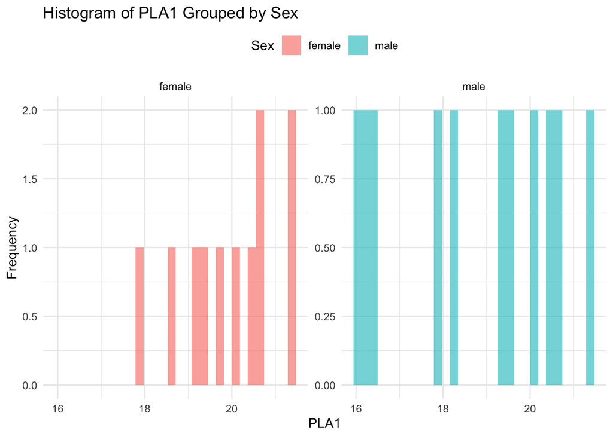

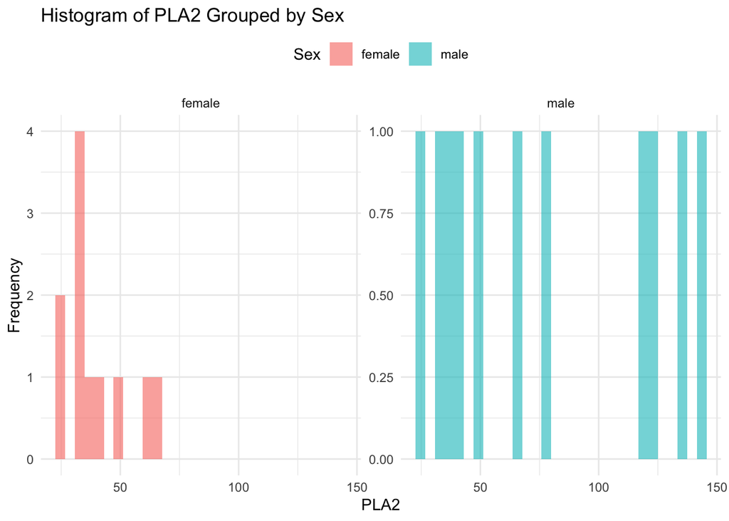

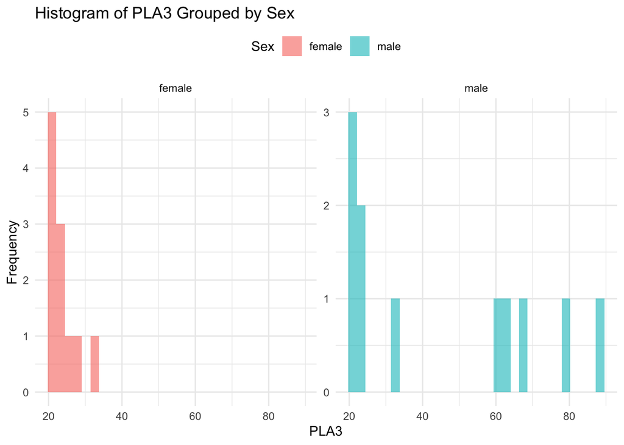

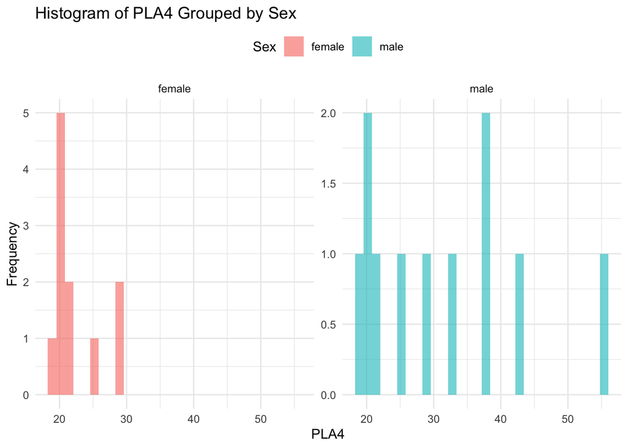

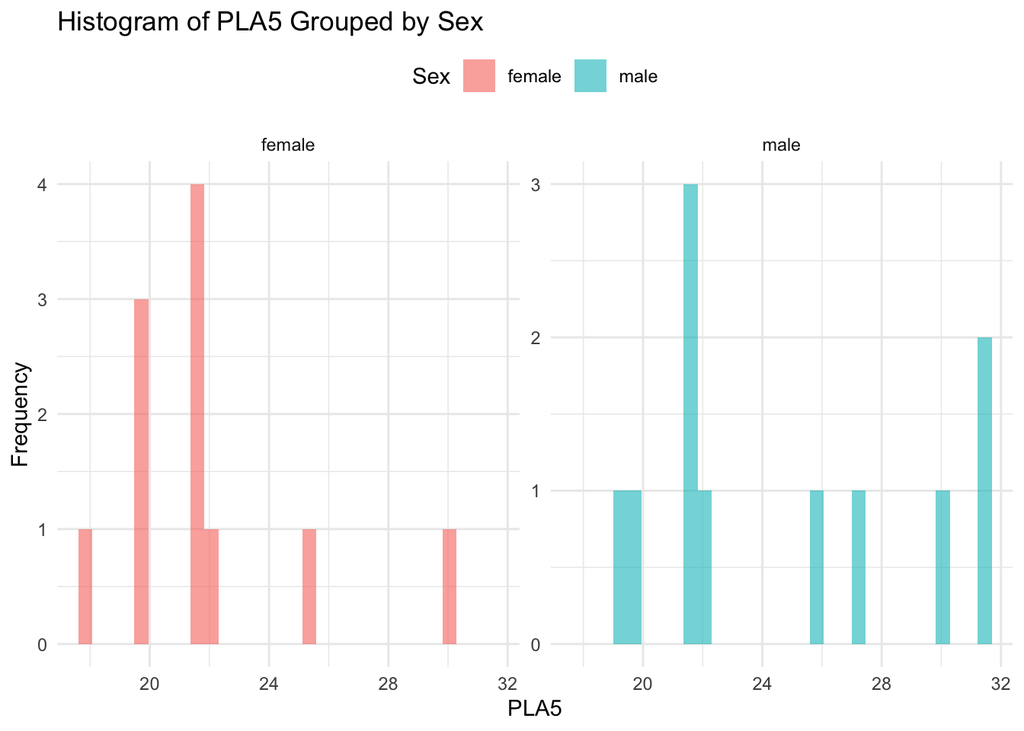

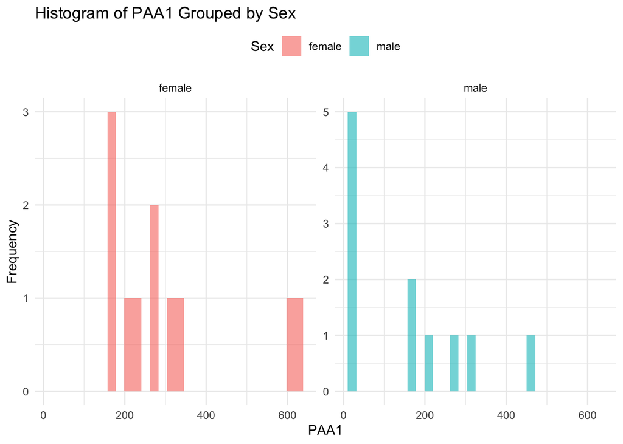

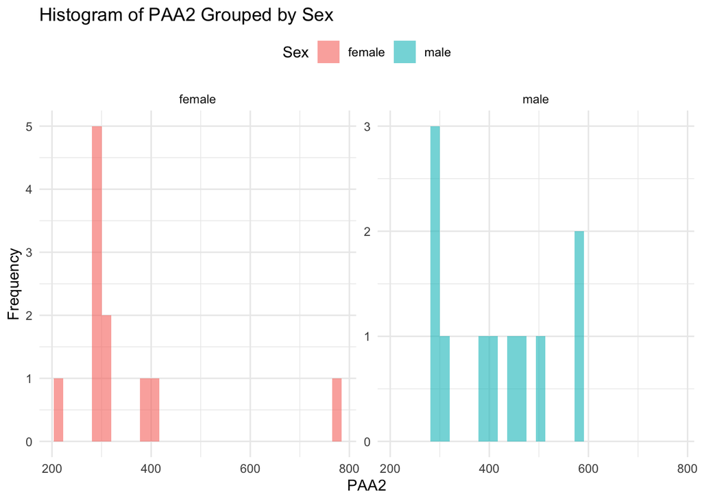

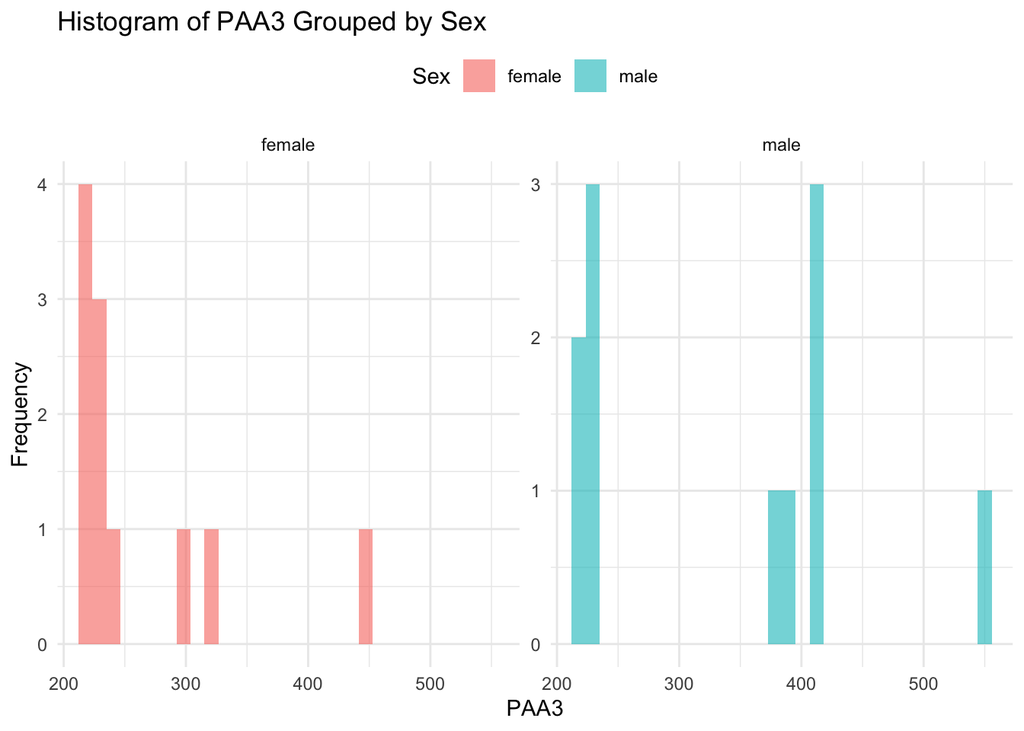

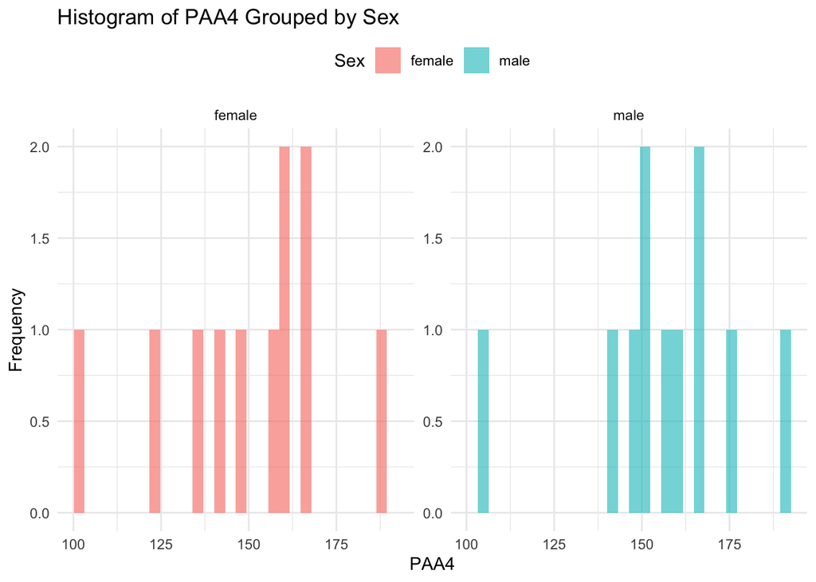

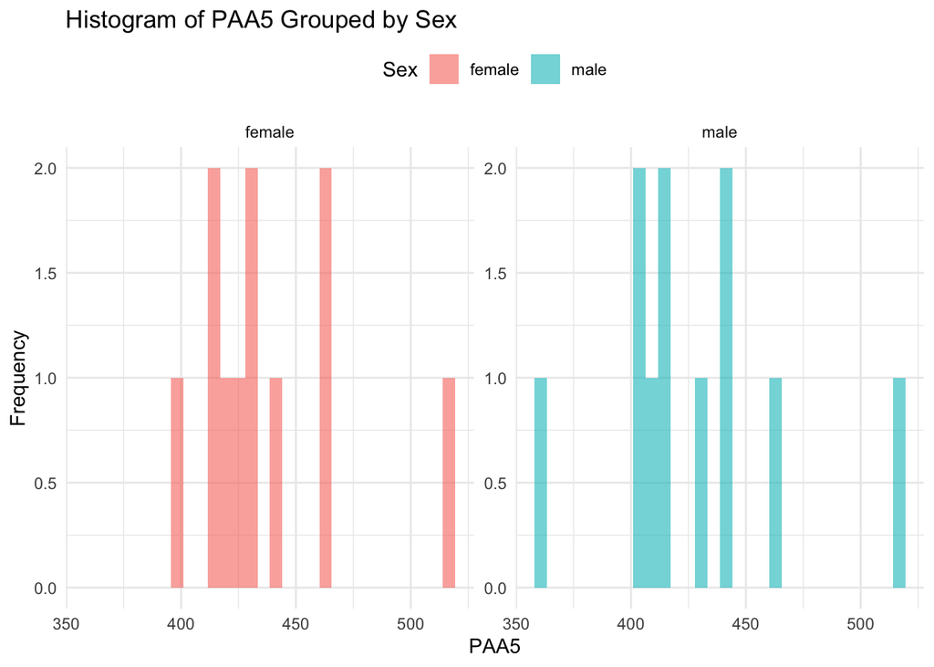

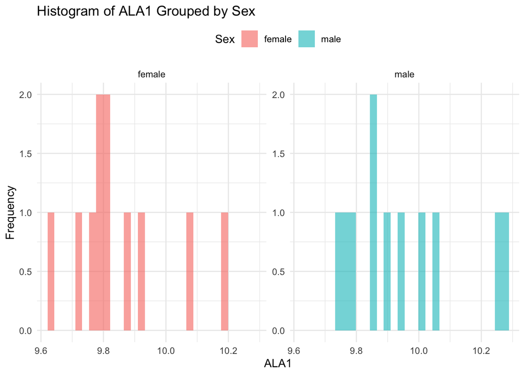

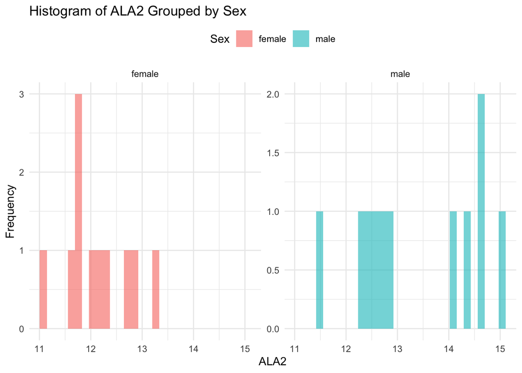

[8 more figures not shown]

```r
library(ggplot2)

# Identify numeric columns excluding 'Sex'
num_cols <- names(data)[sapply(data, is.numeric) & names(data) != "group"]

# Plot histograms for each numeric column, grouped by sex
for (col in num_cols) {
  # Convert to numeric in case some columns are not numeric
  data[[col]] <- as.numeric(data[[col]])

  plot <- ggplot(data, aes_string(x = col, fill = "group")) +
    geom_histogram(alpha = 0.6, position = "identity") +
    labs(title = paste("Histogram of", col, "Grouped by Sex"),
         x = col,
         y = "Frequency") +
    theme_minimal() +
    facet_wrap(~group, scales = "free_y") +
    theme(legend.position = "top") +
    guides(fill = guide_legend(title = "Sex"))

  print(plot)
}
```